# Module R’Stat1 : Les séries temporelles

francois.rebaudo@ird.fr

Novembre 2019 ; IRD-Montpellier-France CC BY-NC-ND 3.0

# Définitions

## Série temporelle

Mesures répétées à un pas de temps donné. Par exemple la température chaque jour, la valeur d’une action chaque semaine, le nombre d’insectes chaque mois, …

Une série temporelle est *régulière* si le pas de temps est toujours le même et *irrégulière* dans le cas contraire. La plupart des analyses statistiques ne s’appliquent qu’aux séries temporelles régulières. La quasi totalité des séries temporelles en biologie sont irrégulières !

!! On ne va que survoler la thématique des séries temporelles qui fait l’objet de nombreux livres et de nombreux packages R !!! Vue d’ensemble ici

## Décomposition

Une série temporelle peut être décomposée en :

- une tendance ou orientation (en général avec un modèle linéaire)
- une composante saisonnière (quelque chose qui revient avec périodicité)
- une composante aléatoire (bruit de fond)
- une composante cyclique (des évènements qui reviennent avec des variations, par exemple El Niño)

## Pour quoi faire ?

Pour décrire, expliquer, faire des hypothèses, modéliser, prévoir, …

# `ts`

```r
# ?ts : The function ts is used to create time-series objects.
myTs <- ts(data = rnorm(45),
  start = c(2016, 2),
  frequency = 12)
print(myTs)
```

```
##              Jan         Feb         Mar         Apr         May
## 2016             -0.66960810  1.13983300 -1.85598599  0.81628493
## 2017 -1.12656474 -0.14393231  1.06762113 -2.30920531  0.47295250
## 2018  0.20322220 -0.20668717  0.15708461 -0.72950695  1.09791403
## 2019  0.96931212  0.15772934 -1.21621748 -0.94901891  3.12868932
##              Jun         Jul         Aug         Sep         Oct
## 2016 -0.17076981  1.08981231  0.74192109 -0.72764400 -0.70373971
## 2017  0.30791470  1.58896050 -0.17352878 -0.87229436 -0.18136641
## 2018 -0.43094538 -0.84162924  0.38198947  1.09339724 -0.71494964
## 2019 -0.16476848  0.38624069  0.82786204 -1.49346438  0.74670559
##              Nov         Dec
## 2016  0.00253112 -1.66704299
## 2017  0.97877421 -0.12194153
## 2018 -0.40475779  0.79466085
## 2019
```

```r
str(myTs)
```

```
##  Time-Series [1:45] from 2016 to 2020: -0.67 1.14 -1.856 0.816 -0.171 ...
```

```r
myTs2 <- ts(data = rnorm(30),
  start = c(2019, 32),
  frequency = 365)
print(myTs2)
```

```
## Time Series:
## Start = c(2019, 32)
## End = c(2019, 61)
## Frequency = 365
##  [1]  0.1892583  2.4191292 -0.9180494 -0.7277307 -1.1643339  0.1161126
##  [7]  0.5771136 -1.8024935  0.6341600  0.6972268  1.5070810 -0.9685960
## [13]  1.7469175  0.7793346  1.5068857 -1.9686809  0.2755536  0.8376550
## [19]  0.5363980  0.4532773 -2.3447569 -0.9409205  1.4031314 -1.1792448
## [25] -3.0580679 -0.9762208  1.5576742 -0.5317512  2.0538006  0.6494285
```

# Mais concrètement, avec des données réelles ?

## Exemple : données météo

Dans la pratique nos séries temporelles viennent d’un fichier. Et le fichier comportera souvent (si ce n’est tout le temps) des données manquantes !

## Charger les données

```r
myData <- read.table("./DATA/bddSept2019.csv", header = TRUE, sep = ",",
  dec = ".")
levelsRasp <- levels(myData$raspid)
newNameRasp <- c("IC", "UP", "PR", "EG", "UT", "EM", "UM", "II")
myData$raspid <- as.character(myData$raspid)
for (i in seq_along(levelsRasp)){
  myData$raspid <- gsub(
    pattern = levelsRasp[i],
    replacement = newNameRasp[i],
    x = myData$raspid)
}
myData$raspid <- as.factor(myData$raspid)
```

## Dates au format POSIXct

```r
myData$timestamp <- as.POSIXct(myData$timestamp)
str(myData)
```

```
## 'data.frame':    188184 obs. of  19 variables:
##  $ raspid      : Factor w/ 8 levels "EG","EM","IC",..: 1 1 1 1 1 1 1 1 1 1 ...
##  $ timestamp   : POSIXct, format: "2019-09-01 00:11:16" "2019-09-01 00:12:19" ...
##  $ temperature : num  22.4 22.4 24.1 22.3 22.3 ...
##  $ gas         : int  5797414 5797414 6552984 5797414 5797414 6593137 5797414 11127198 6593137 5797414 ...
##  $ humidity    : num  59.2 59.2 49.4 59.1 59 ...
##  $ pressure    : num  1009 1009 1010 1010 1010 ...
##  $ lightvisible: int  261 260 299 260 260 301 260 276 301 260 ...
##  $ lightir     : int  254 253 648 253 254 673 255 392 670 253 ...
##  $ lightuv     : int  2 2 23 2 2 24 2 10 24 2 ...
##  $ ndvi_0      : int  307200 307200 237139 307200 307200 230841 307200 224441 241853 307200 ...
##  $ ndvi_1      : int  0 0 0 0 0 0 0 954 0 0 ...
##  $ ndvi_2      : int  0 0 0 0 0 0 0 15 0 0 ...
##  $ ndvi_3      : int  0 0 0 0 0 0 0 0 0 0 ...
##  $ ndvi_4      : int  0 0 0 0 0 0 0 0 0 0 ...
##  $ ndvi_5      : int  0 0 0 0 0 0 0 0 0 0 ...
##  $ ndvi_6      : int  0 0 0 0 0 0 0 0 0 0 ...
##  $ ndvi_7      : int  0 0 0 0 0 0 0 0 0 0 ...
##  $ ndvi_8      : int  0 0 0 0 0 0 0 0 0 0 ...
##  $ ndvi_9      : int  0 0 0 0 0 0 0 0 0 0 ...
```

```r
myData <- myData[order(myData$timestamp),]
```

## Aperçu des données

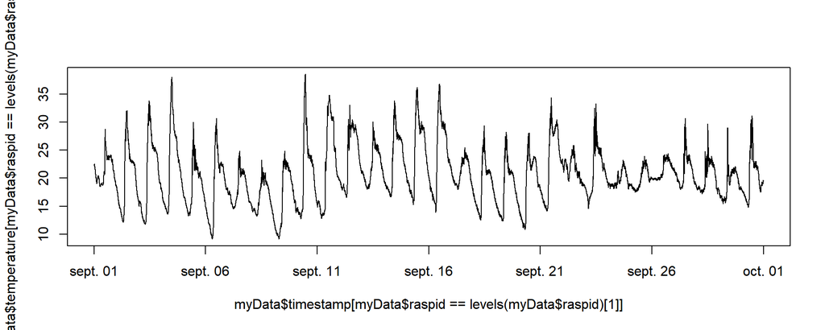

```r
plot(x = myData$timestamp[myData$raspid == levels(myData$raspid)[1]],
  y = myData$temperature[myData$raspid == levels(myData$raspid)[1]],
  type = 'l')
```

## Séparer les différentes mesures

```r
listTemp <- lapply(levels(myData$raspid), function(myId){
  x <- tapply(
    myData$temperature[myData$raspid == myId],
    INDEX = format(
      myData$timestamp[myData$raspid == myId],
      "%Y-%m-%d %H"),
    FUN = mean, na.rm = TRUE)
  data.frame(date = names(x), temp = x)
})
```

## Mettre chaque mesure dans une colonne d’un `data.frame`

```r
tmp <- merge(listTemp[[1]], listTemp[[2]], by.x = 1, by.y = 1,
  all = TRUE)
tmp <- merge(tmp, listTemp[[3]], by.x = 1, by.y = 1, all = TRUE)
tmp <- merge(tmp, listTemp[[4]], by.x = 1, by.y = 1, all = TRUE)
tmp <- merge(tmp, listTemp[[5]], by.x = 1, by.y = 1, all = TRUE)
tmp <- merge(tmp, listTemp[[6]], by.x = 1, by.y = 1, all = TRUE)
tmp <- merge(tmp, listTemp[[7]], by.x = 1, by.y = 1, all = TRUE)
tmp <- merge(tmp, listTemp[[8]], by.x = 1, by.y = 1, all = TRUE)
tmp <- tmp[order(as.POSIXct(tmp$date, format = "%Y-%m-%d %H")),]
colnames(tmp) <- c("date", levels(myData$raspid))
tmp$date <- as.POSIXct(tmp$date, format = "%Y-%m-%d %H")
```

## Identifier le nombre de données manquantes

```r
sapply(2:9, function(i){sum(is.na(tmp[,i]))})
```

```
## [1]   0  51 286 563 271 325 174 718
```

```r
paste0(round(
  sapply(2:9, function(i){sum(is.na(tmp[,i]))}) / (30*24) * 100,
  digits = 1), "%")
```

```
## [1] "0%"    "7.1%"  "39.7%" "78.2%" "37.6%" "45.1%" "24.2%" "99.7%"
```

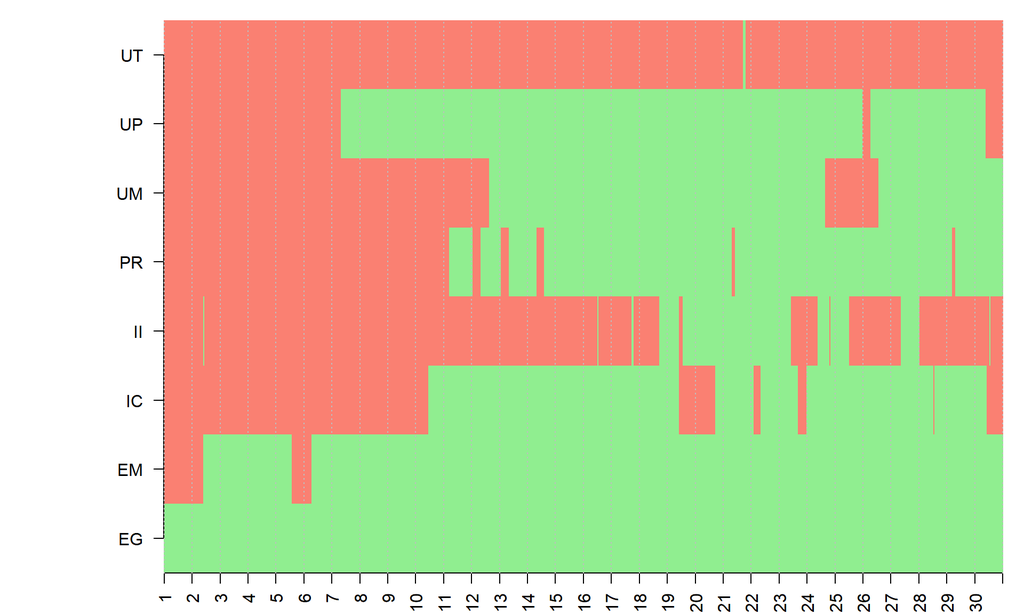

```r
par(mar = c(2, 8, 1, 1))
image(sapply(2:9, function(i){is.na(tmp[,i])}),
  axes = FALSE, col = c("lightgreen", "salmon"))
axis(
  2, labels = levels(myData$raspid), las = 1,
  at = seq(
    from = 0, to = 1,
    length.out = length(levels(myData$raspid))))
axis(1, at = seq(from = 0, to = 1, length.out = 31),
  labels = c(1:30, ""), las = 3)
abline(v = seq(from = 0, to = 1, length.out = 31),
  lty = 3, col = "gray")
```

```r
which(is.na(tmp$EM))
```

```
##  [1]   1   2   3   4   5   6   7   8   9  10  11  12  13  14  15  16  17
## [18]  18  19  20  21  22  23  24  25  26  27  28  29  30  31  32  33  34
## [35] 111 112 113 114 115 116 117 118 119 120 121 122 123 124 125 126 127
```

## Que faire ?

```r
print(tmp[is.na(tmp$EM),c("date", "EM")])
```

```
##                    date EM
## 1   2019-09-01 00:00:00 NA
## 2   2019-09-01 01:00:00 NA
## 3   2019-09-01 02:00:00 NA
## 4   2019-09-01 03:00:00 NA
## 5   2019-09-01 04:00:00 NA
## 6   2019-09-01 05:00:00 NA
## 7   2019-09-01 06:00:00 NA
## 8   2019-09-01 07:00:00 NA
## 9   2019-09-01 08:00:00 NA
## 10  2019-09-01 09:00:00 NA
## 11  2019-09-01 10:00:00 NA
## 12  2019-09-01 11:00:00 NA
## 13  2019-09-01 12:00:00 NA
## 14  2019-09-01 13:00:00 NA
```

[output cut: 37 more lines]

## Remplacer les valeurs manquantes par la moyenne de la température à la même heure ?

```r
mean(tmp$EM[format(tmp$date, "%H") == "00"], na.rm = TRUE)
```

```
## [1] 18.86718
```

```r
sd(tmp$EM[format(tmp$date, "%H") == "00"], na.rm = TRUE)
```

```
## [1] 1.354671
```

```r
tmpEM <- data.frame(
  date = tmp$date,
  EM = tmp$EM,
  com = "", stringsAsFactors = FALSE
)
hours <- c(paste0("0", 0:9), 10:23)
for(i in hours){
  tmpEM$com[is.na(tmpEM$EM) & format(tmpEM$date, "%H") == i] <- "Fake"
  tmpEM$EM[is.na(tmpEM$EM) & format(tmpEM$date, "%H") == i] <-
    mean(tmp$EM[format(tmp$date, "%H") == i], na.rm = TRUE)
}
tmpEM$com <- as.factor(tmpEM$com)
```

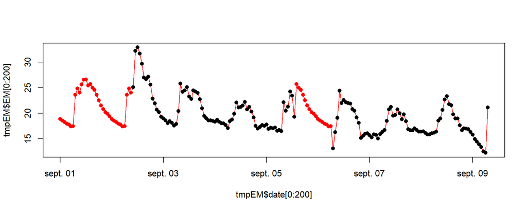

```r
plot(x = tmpEM$date[0:200],
  y = tmpEM$EM[0:200],
  col = tmpEM$com[0:200],
  pch = 16, type = 'o')
```

## Autres idées ?

- Remplacer par la médiane ?
- Prendre une valeur au hasard ?

## Le package imputeTS

```r
library("imputeTS")
tmpEM2 <- data.frame(
  date = tmp$date,
  EM = tmp$EM,
  com = "", stringsAsFactors = FALSE
)
statsNA(as.vector(tmpEM2$EM))
```

```
## [1] "Length of time series:"
## [1] 720
## [1] "-------------------------"
## [1] "Number of Missing Values:"
## [1] 51
## [1] "-------------------------"
## [1] "Percentage of Missing Values:"
## [1] "7.08%"
## [1] "-------------------------"
## [1] "Stats for Bins"
## [1] "  Bin 1 (180 values from 1 to 180) :      51 NAs (28.3%)"
## [1] "  Bin 2 (180 values from 181 to 360) :      0 NAs (0%)"
## [1] "  Bin 3 (180 values from 361 to 540) :      0 NAs (0%)"
## [1] "  Bin 4 (180 values from 541 to 720) :      0 NAs (0%)"
## [1] "-------------------------"
## [1] "Longest NA gap (series of consecutive NAs)"
## [1] "34 in a row"
## [1] "-------------------------"
## [1] "Most frequent gap size (series of consecutive NA series)"
## [1] "34 NA in a row (occuring 1 times)"
## [1] "-------------------------"
## [1] "Gap size accounting for most NAs"
## [1] "34 NA in a row (occuring 1 times, making up for overall 34 NAs)"
## [1] "-------------------------"
## [1] "Overview NA series"
## [1] "  17 NA in a row: 1 times"
## [1] "  34 NA in a row: 1 times"
```

## `?na.kalman`

```r
# Missing Value Imputation by Kalman Smoothing and State Space Models
tmpEM2$kalman <- na.kalman(as.vector(tmpEM2$EM))
# Missing Value Imputation by Last Observation Carried Forward
tmpEM2$locf <- na.locf(as.vector(tmpEM2$EM))
# Missing Value Imputation by Weighted Moving Average
tmpEM2$ma <- na.ma(as.vector(tmpEM2$EM))
# Seasonally Decomposed Missing Value Imputation
tmpEM2$seadec <- na.seadec(as.vector(tmpEM2$EM))
# Seasonally Splitted Missing Value Imputation
tmpEM2$seasplit <- na.seasplit(as.vector(tmpEM2$EM))
# Missing Value Imputation by Interpolation
tmpEM2$interpolation <- na.interpolation(as.vector(tmpEM2$EM))
```

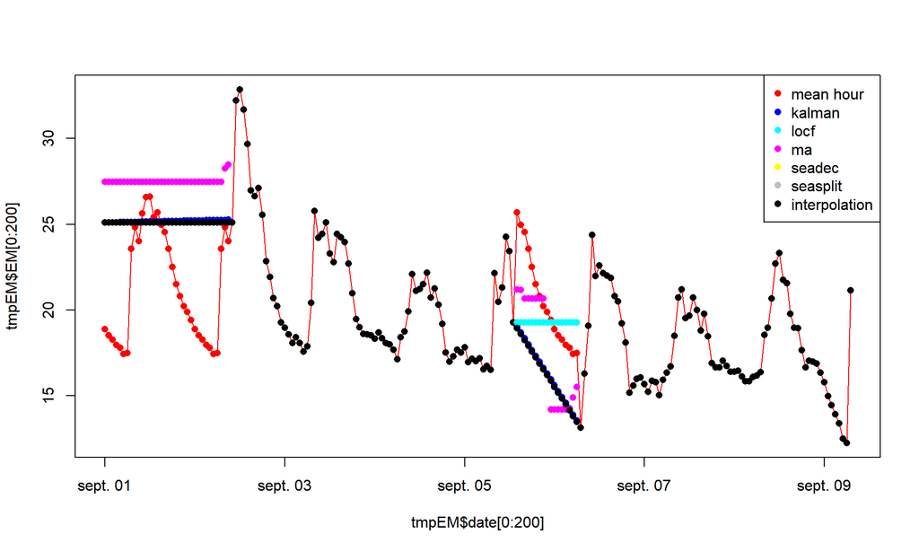

```r
plot(x = tmpEM$date[0:200],
  y = tmpEM$EM[0:200],
  col = tmpEM$com[0:200],
  pch = 16, type = 'o')
for(i in 4:9){
  points(x = tmpEM2$date[c(1:34, 111:127)],
    y = tmpEM2[c(1:34, 111:127),i],
    col = i, pch = 16, type = 'p')
}
legend("topright",
  legend = c("mean hour", names(tmpEM2)[4:9]),
  col = c(2, 4:9), pch = 16)
```

# Mais concrètement, avec des données réelles ? (2)

## Exemple : mesures humaines

Quand les relevés sont faits par des humains (sondage, piégeage, mesure physique, …), par exemple tous les 10 jours, et bien il y a toujours un jour qui tombe un samedi ou un dimanche, ou alors il y avait (encore) une réunion… Bref : la série n’est pas régulière !

Option 1 (tristement la plus courante) : fermer les yeux très fort, des fois que…

Option 2 : régler le problème en faisant des hypothèses sur la distribution des données

## Données théoriques

```r
set.seed(1234)
x <- as.Date("01/01/2017", format = "%d/%m/%Y") +
  sapply(1:100, function(i){
    if(sample(1:4, size = 1) == 1){
      return(10 * i + sample(1:3, size = 1))
    } else {
      return(10 * i)
    }
  })
y <- round(rnorm(100, mean = 100, sd = 20))
df <- data.frame(x, y)
```

```r
difDate<-vector()
for (i in seq(nrow(df) - 1)){
    difDate<-c(difDate,(df$x[i + 1] - df$x[i]))
}
```

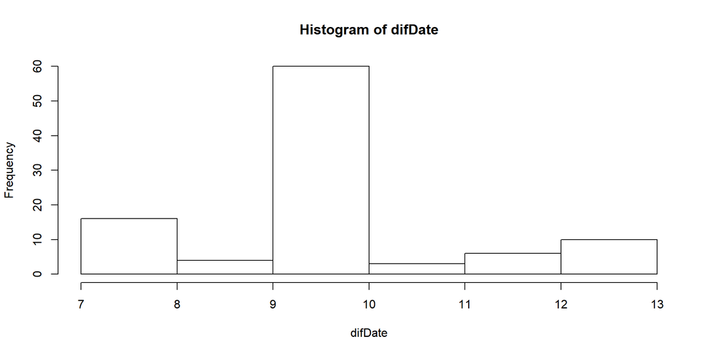

```r
hist(difDate)
```

## Cas 1 : mesures accumulée (qt/unité de temps)

## transformation avec l’écart à la moyenne

```r
mean(difDate)
```

```
## [1] 10
```

```r
correct <- c(1, 1 - (difDate - mean(difDate))/mean(difDate))
newDate <- seq(
  from = df$x[1],
  to = tail(df$x,1),
  length.out = nrow(df))
newY <- df$y * correct
newDf <- data.frame(x = newDate, y = newY)
head(newDf)
```

```
##            x     y
## 1 2017-01-11  91.0
## 2 2017-01-21 107.0
## 3 2017-01-31  96.0
## 4 2017-02-10  98.0
## 5 2017-02-20  73.5
## 6 2017-03-02 146.4
```

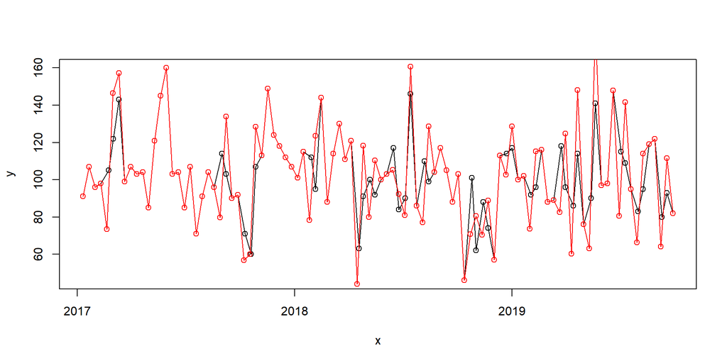

```r
plot(df, type = 'o')
points(newDf, type = 'o', col = 2)
```

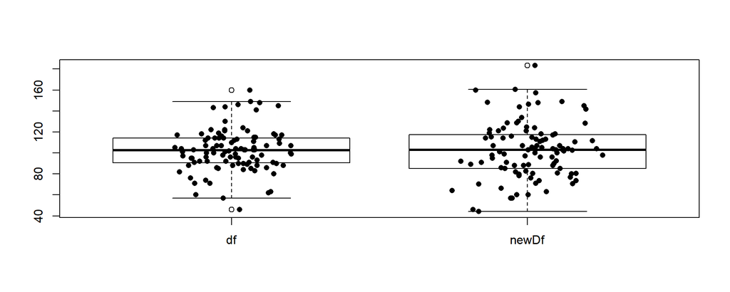

```r
boxplot(df$y, newDf$y, names = c("df", "newDf"))
points(x = rnorm(nrow(df), mean = 1, sd = 0.1),
  y = df$y, pch = 16)
points(x = rnorm(nrow(newDf), mean = 2, sd = 0.1),
  y = newDf$y, pch = 16)
```

```r
t.test(df$y, newDf$y)
```

```
##
##  Welch Two Sample t-test
##
## data:  df$y and newDf$y
## t = -0.055922, df = 185.83, p-value = 0.9555
## alternative hypothesis: true difference in means is not equal to 0
## 95 percent confidence interval:
##  -6.783969  6.409969
## sample estimates:
## mean of x mean of y
##   102.480   102.667
```

## Cas 2 : mesures ponctuelles (qt)

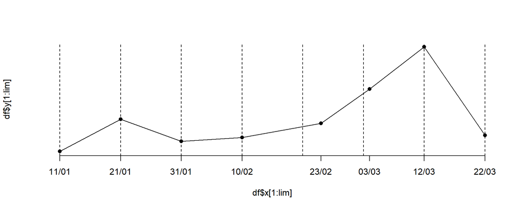

```r
lim <- 8
plot(x = df$x[1:lim], y = df$y[1:lim], axes = FALSE, type = 'o', pch = 16)
axis(1, at = df$x[1:lim], labels = format(df$x[1:lim], "%d/%m"))
abline(v = c(seq(from = df$x[1], to = df$x[lim], by = 10)), lty = 2)
```

```r
difSeq <- df$x - seq(
  from = df$x[1],
  to = tail(df$x, 1),
  length.out = nrow(df))
print(difSeq)
```

```
## Time differences in days
##   [1] 0 0 0 0 3 1 0 0 0 0 0 0 0 0 0 0 0 0 0 0 0 0 0 3 0 0 0 2 2 0 0 0 0 0 0
##  [36] 0 0 0 3 0 0 0 0 0 0 0 3 0 2 0 0 0 1 0 1 0 0 3 0 0 0 0 0 0 0 3 0 2 0 0
##  [71] 0 1 0 0 0 2 0 0 0 0 3 0 3 0 0 3 0 0 0 0 3 0 0 2 0 0 0 2 0 0
```

```r
newDate <- seq(
  from = df$x[1],
  to = tail(df$x,1),
  length.out = nrow(df))
newY <- df$y
objDate <- 10
for(i in which(difSeq != 0)){
  yModel <- lm(newY[c(i-1, i)] ~ c(newDate[i - 1], df$x[i]))
  newY[i] <- yModel$coefficients[1] +
    yModel$coefficients[2]*as.numeric(newDate[i-1] + objDate)
}
newDf <- data.frame(x = newDate, y = newY)
```

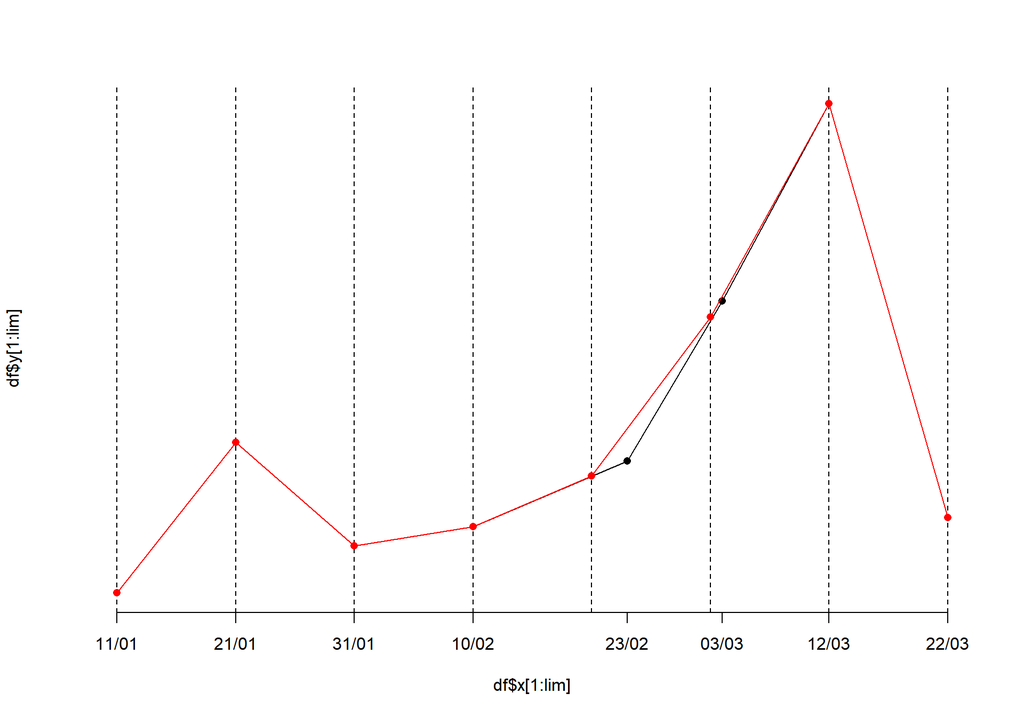

```r
lim <- 8
plot(x = df$x[1:lim], y = df$y[1:lim], axes = FALSE, type = 'o', pch = 16)
axis(1, at = df$x[1:lim], labels = format(df$x[1:lim], "%d/%m"))
abline(v = c(seq(from = df$x[1], to = df$x[lim], by = 10)), lty = 2)
points(
  x = newDf$x[1:lim],
  y = newDf$y[1:lim], col = 2,
  type = 'o', pch = 16)
```

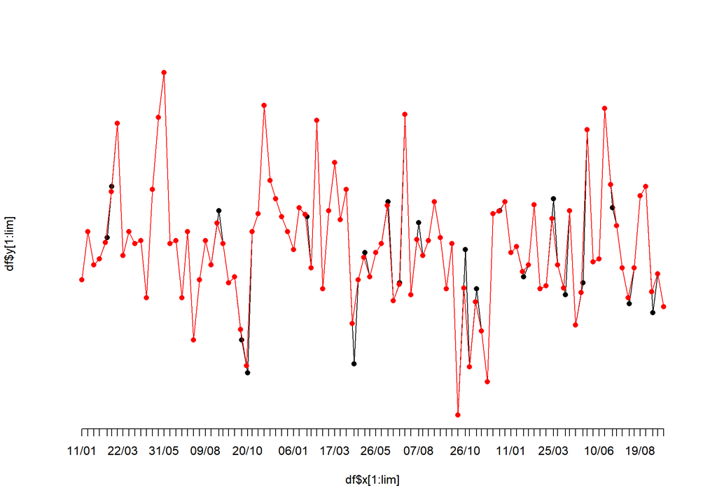

```r
lim <- nrow(df)
plot(x = df$x[1:lim], y = df$y[1:lim], axes = FALSE, type = 'o', pch = 16)
axis(1, at = df$x[1:lim], labels = format(df$x[1:lim], "%d/%m"))
points(
  x = newDf$x[1:lim],
  y = newDf$y[1:lim], col = 2,
  type = 'o', pch = 16)
```

Ici nous ne voyons que quelques options simples…

# Quand enfin tout va bien :

## On peut travailler avec les séries temporelles !

Remarque : il existe des cas où il est possible de travailler avec des séries temporelles irrégulières…

## Données météo

```r
myData <- read.table("./DATA/bddSept2019.csv", header = TRUE, sep = ",",
  dec = ".")
levelsRasp <- levels(myData$raspid)
newNameRasp <- c("IC", "UP", "PR", "EG", "UT", "EM", "UM", "II")
myData$raspid <- as.character(myData$raspid)
for (i in seq_along(levelsRasp)){
  myData$raspid <- gsub(
    pattern = levelsRasp[i],
    replacement = newNameRasp[i],
    x = myData$raspid)
}
myData$raspid <- as.factor(myData$raspid)
myData$timestamp <- as.POSIXct(myData$timestamp)
myData <- myData[order(myData$timestamp),]
listTemp <- lapply(levels(myData$raspid), function(myId){
  x <- tapply(
    myData$temperature[myData$raspid == myId],
    INDEX = format(
      myData$timestamp[myData$raspid == myId],
      "%Y-%m-%d %H"),
    FUN = mean, na.rm = TRUE)
  data.frame(date = names(x), temp = x)
})
tmp <- merge(listTemp[[1]], listTemp[[2]], by.x = 1, by.y = 1,
  all = TRUE)
tmp <- merge(tmp, listTemp[[3]], by.x = 1, by.y = 1, all = TRUE)
tmp <- merge(tmp, listTemp[[4]], by.x = 1, by.y = 1, all = TRUE)
tmp <- merge(tmp, listTemp[[5]], by.x = 1, by.y = 1, all = TRUE)
tmp <- merge(tmp, listTemp[[6]], by.x = 1, by.y = 1, all = TRUE)
tmp <- merge(tmp, listTemp[[7]], by.x = 1, by.y = 1, all = TRUE)
tmp <- merge(tmp, listTemp[[8]], by.x = 1, by.y = 1, all = TRUE)
tmp <- tmp[order(as.POSIXct(tmp$date, format = "%Y-%m-%d %H")),]
colnames(tmp) <- c("date", levels(myData$raspid))
tmp$date <- as.POSIXct(tmp$date, format = "%Y-%m-%d %H")
```

## ts

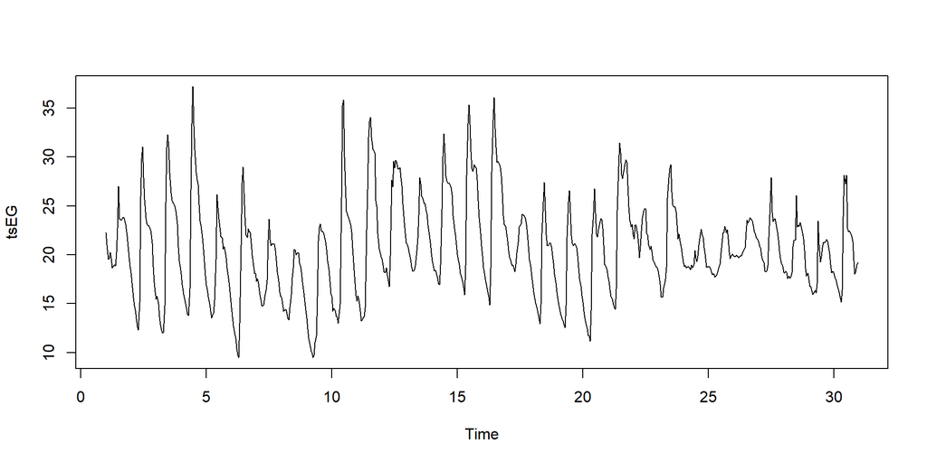

```r
tsEG <- ts(tmp$EG, frequency = 24)
plot(tsEG)
```

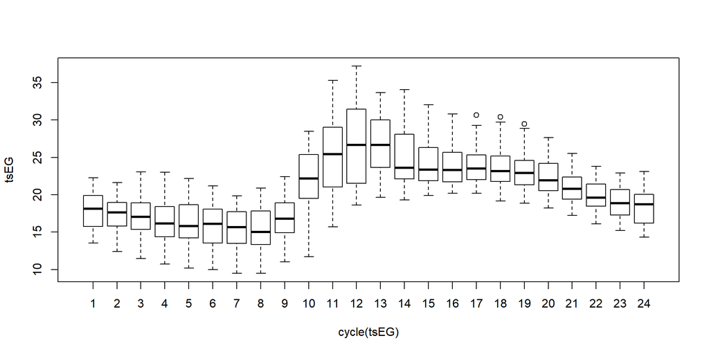

```r
boxplot(tsEG ~ cycle(tsEG))
```

```r
# effet "heure" très fort
```

## Décomposition de la série temporelle

```r
decompEG <- decompose(tsEG)
print(decompEG)
```

```
## $x
## Time Series:
## Start = c(1, 1)
## End = c(30, 24)
## Frequency = 24
##   [1] 22.273168 21.037693 19.545947 19.601642 20.272462 19.633283 18.663302
##   [8] 18.842599 18.952720 18.888261 20.229870 22.692596 26.987959 23.698750
##  [15] 23.572174 23.595759 23.792630 23.868487 23.479944 23.118936 21.901572
##  [22] 20.851323 19.750172 18.828811 18.170570 17.156384 15.625388 14.836387
##  [29] 14.332974 13.505771 12.691493 12.327269 15.104249 25.970046 29.875693
##  [36] 31.029839 27.884496 25.673849 23.735647 23.160990 22.987806 22.951892
##  [43] 22.776070 22.457206 21.160521 18.764015 17.192274 16.225878 15.475508
##  [50] 15.767551 14.993237 13.637285 12.847993 12.366448 11.997856 12.059026
##  [57] 14.833673 25.359393 30.982937 32.263853 30.973705 28.392066 26.315561
##  [64] 25.570692 25.317558 25.191575 24.909684 24.427783 23.152553 20.810441
```

[output cut: 490 more lines]

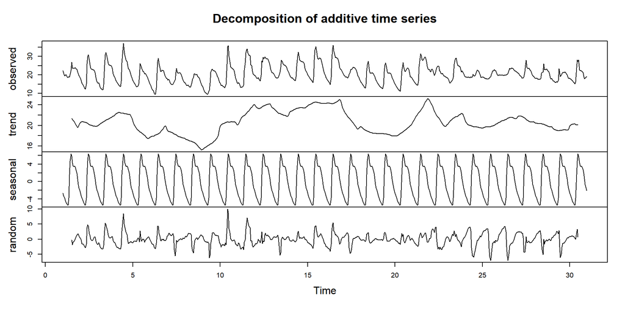

```r
plot(decompEG)
```

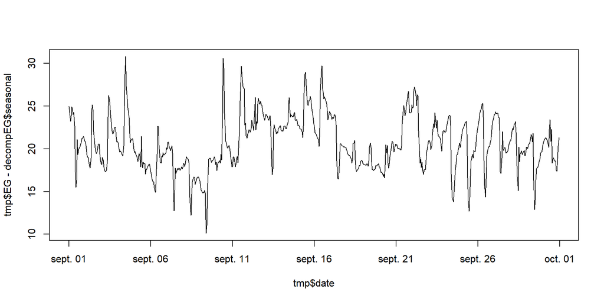

```r
plot(x = tmp$date,
  y = tmp$EG - decompEG$seasonal, type = 'l')
```

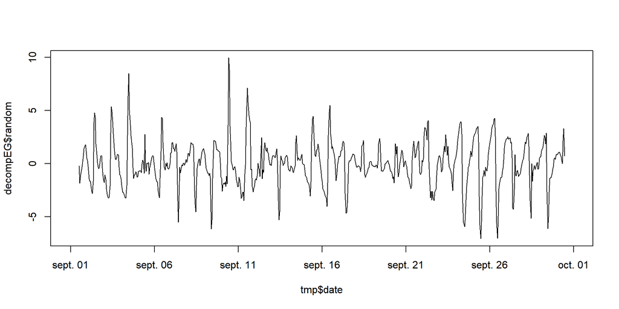

```r
plot(x = tmp$date,
  y = decompEG$random, type = 'l')
```

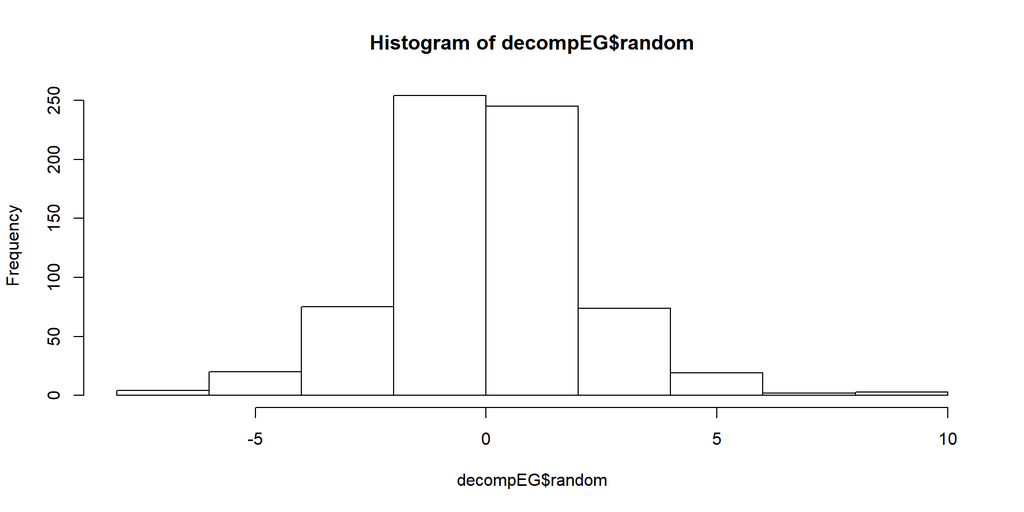

```r
hist(decompEG$random)
```

```r
shapiro.test(decompEG$random)
```

```
##
##  Shapiro-Wilk normality test
##
## data:  decompEG$random
## W = 0.97655, p-value = 4.045e-09
```

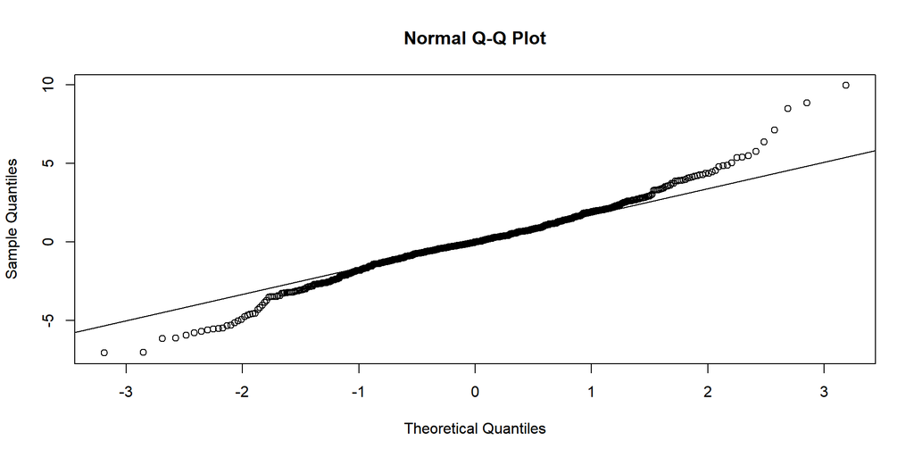

```r
qqnorm(decompEG$random)
qqline(decompEG$random)
```

## ARMA : “auto-regression” et “moving average”

=> seuleument pour les séries temporelles stationnaires :

- pas de tendance
- variance stable

```r
myTs <- tsEG - decompEG$trend + mean(tsEG)
myTs <- myTs[!is.na(myTs)]
```

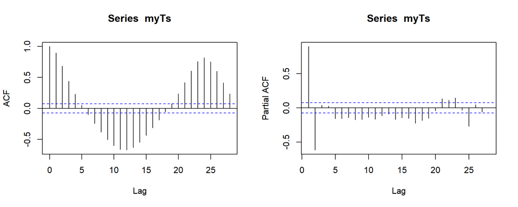

```r
par(mfrow = c(1, 2))
acf(myTs)
pacf(myTs)
```

## prévisions avec ARIMA : auto-regressive integrated moving average

AR : auto-regressive (p = délais dans l’autocorrélation)

I : integrated (d = différenciation ; rendre stationnaire une ts)

MA : moving average (q = délais dans l’accumulation des erreurs)

## Prévisions avec ARIMA

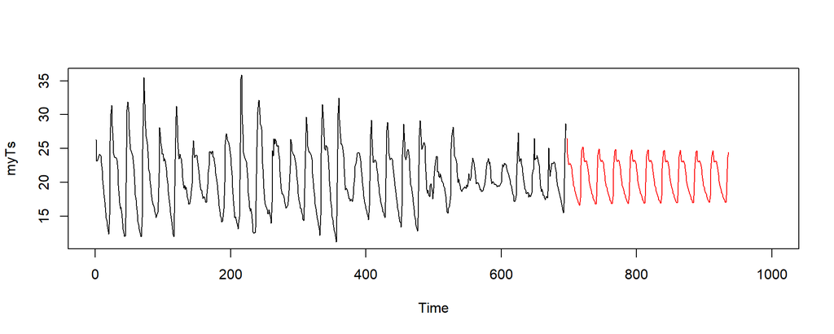

```r
fit <- arima(myTs, c(2, 0, 1), seasonal = list(order = c(2, 0, 1), period = 24))
pred <- predict(fit, n.ahead = 10*24)
ts.plot(myTs, xlim = c(0, 1000))
points(pred$pred, col = 2, type = 'l')
```

## Prévisions avec Holt-Winters Exponential Smoothing

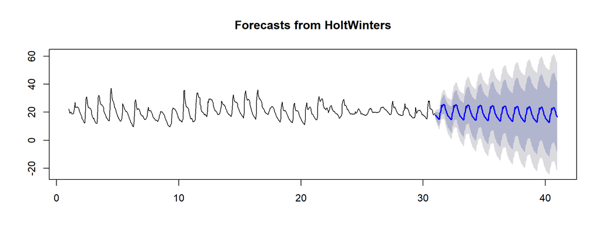

```r
library("forecast")
modL <- HoltWinters(tsEG)
modLprev <- forecast(modL, h = 10*24)
plot(modLprev)
```

## Pour approfondir

[Forecasts using Exponential Smoothing](https://a-little-book-of-r-for-time-series.readthedocs.io/en/latest/src/timeseries.html)

## La cross-corrélation

Corrélation entre deux variables avec délais ?

D’après E. E. Holmes, M. D. Scheuerell, and E. J. Ward, 2019. Applied Time Series Analysis for Fisheries and Environmental Sciences

lynx : Annual numbers of lynx trappings for 1821–1934 in Canada. Taken from Brockwell & Davis (1991), this appears to be the series considered by Campbell & Walker (1977).

sunspot.year : Yearly numbers of sunspots from 1700 to 1988 (rounded to one digit).

```r
## get the matching years of sunspot data
suns <- ts.intersect(lynx, sunspot.year)[,"sunspot.year"]
## get the matching lynx data
lynx <- ts.intersect(lynx, sunspot.year)[,"lynx"]
```

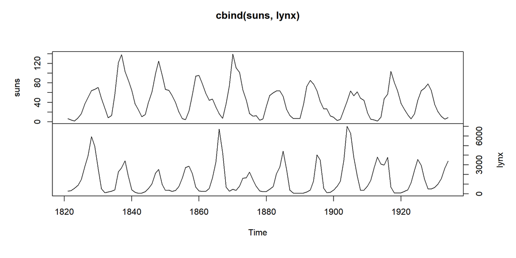

```r
plot(cbind(suns, lynx), yax.flip = TRUE)
```

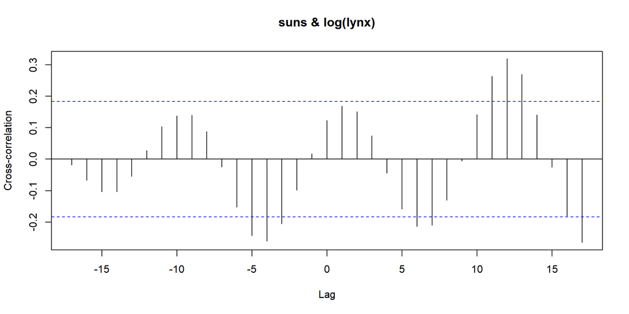

```r
# it looks like lynx numbers are relatively low 3-5 years after high sunspot activity
ccf(suns, log(lynx), ylab = "Cross-correlation")
```

## Pour approfondir

[Applied Time Series Analysis for Fisheries and Environmental Sciences](https://nwfsc-timeseries.github.io/atsa-labs/sec-tslab-correlation-within-and-among-time-series.html)

## TD

Tester la cross-correlation et les auto-corrélations pour les données de bdd.csv pour les valeurs agrégées par jour des mois de juillet et août 2019, puis par heure.

# Le modèle linéaire généralisé